# Understanding Heart Disease: The 5 Most Important Features in Prediction

Naoise Carolan

December 14, 2025

### Introduction

As the leading cause of death globally, heart disease is a topic of great importance in medical research with billions of dollars invested every year. Understanding the development and progression of heart disease can help scientists and medical professionals develop more effective prevention methods, screening, and treatment which could save millions of lives in the United States alone. For this project, I chose to use a dataset sourced on Kaggle (https://www.kaggle.com/datasets/fedesoriano/heart-failure-prediction) that contains data from 5 different hospitals in the US and Europe with 11 predictors of heart disease. In order to identify which factors are the most critical in the detection of heart disease, I decided to train a random forest model to predict whether or not a patient had heart disease using these features and then found the 5 most important variables for heart disease prediction from this data. Models like this can be used in medical settings to streamline monitoring and detection of cardiovascular disease, potentially leading to better outcomes for patients at high risk for developing heart disease.

```r
#load necessary packages
library(tidyverse)
library(randomForest)
library(caret)
library(pROC)
library(ggplot2)
library(rpart)
library(rpart.plot)
library(mdsr)
#add quarto
#quarto add qmd-lab/closeread
```

### Part 1: Data Wrangling

This dataset did not require an extensive amount of data wrangling to be usable for the purposes of this project. In order to work with this dataset I got rid of missing values using ‘na.omit’. I then made the HeartDisease variable a factor with ‘as.factor’ and added levels of “noHeartDisease” or “heartDisease”, which made classification possible later on.

```r
#add levels to data
heartClean = na.omit(heart)
heartClean$HeartDisease = as.factor(heartClean$HeartDisease)
levels(heartClean$HeartDisease) = c("noHeartDisease", "heartDisease")
```

### Part 2: Create Random Forest Model

In order to find the 5 most important factors in predicting heart disease, I decided to use a random forest model. To create the random forest model I first split my data into 80% training and 20% testing data.

```r
#split data into test and train
set.seed(876)
train.index = createDataPartition(heartClean$HeartDisease, p = 0.8, list = F)
train = heartClean[train.index,]
test = heartClean[-train.index,]
```

A random forest model was then fit to predict heart disease using all of the features in the dataset. For this model, importance is set to true so that we can find variable importance measures later to determine the most important variables.

```r
#fit model using all features
set.seed(876)
rfModel = randomForest(HeartDisease ~., data = train, importance = T)
rfModel
```

```
##
## Call:
##  randomForest(formula = HeartDisease ~ ., data = train, importance = T)
##                Type of random forest: classification
##                      Number of trees: 500
## No. of variables tried at each split: 3
##
##         OOB estimate of  error rate: 13.74%
## Confusion matrix:
##                noHeartDisease heartDisease class.error
## noHeartDisease            272           56   0.1707317
## heartDisease               45          362   0.1105651
```

```r
#pick number of trees
set.seed(876)
oob.error.data = data.frame(
  Trees = rep(1:nrow(rfModel$err.rate), times = 3),
  Type = rep(c("OOB", "Heart Disease", "No Heart Disease"), each = nrow(rfModel$err.rate)),
  Error = c(rfModel$err.rate[,"OOB"],
            rfModel$err.rate[,"noHeartDisease"],
            rfModel$err.rate[,"heartDisease"]))
```

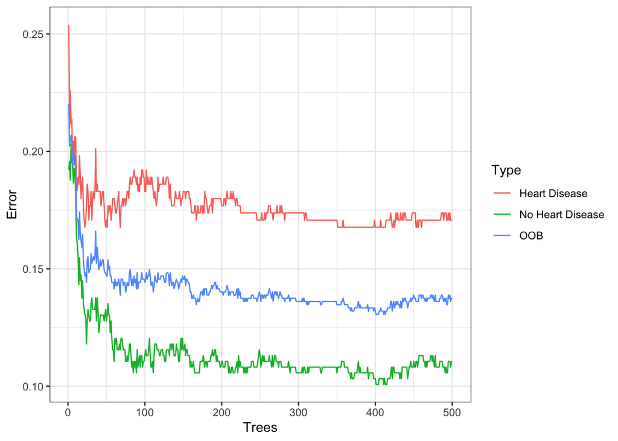

```r
#plot oob.error.data
ggplot(data = oob.error.data, aes(x = Trees, y = Error)) +
  geom_line(aes(color = Type)) + theme_bw()
```

```r
#tune number of features at splits
set.seed(876)
tune.grid = expand.grid(mtry = 1:10)
ctrl = trainControl(method = "oob")
rfTuned = train(HeartDisease ~.,
                data = train,
                method = "rf",
                trControl = ctrl,
                tuneGrid = tune.grid,
                ntree = 480)
rfTuned
```

```
## Random Forest
##
## 735 samples
##  11 predictor
##   2 classes: 'noHeartDisease', 'heartDisease'
##
## No pre-processing
## Resampling results across tuning parameters:
##
##   mtry  Accuracy   Kappa
##    1    0.8693878  0.7327171
##    2    0.8707483  0.7374655
##    3    0.8653061  0.7265738
##    4    0.8503401  0.6961029
##    5    0.8598639  0.7150187
##    6    0.8517007  0.6987762
##    7    0.8530612  0.7018054
##    8    0.8544218  0.7046541
##    9    0.8489796  0.6939763
##   10    0.8462585  0.6879075
##
## Accuracy was used to select the optimal model using the largest value.
## The final value used for the model was mtry = 2.
```

After fitting the model using mtry values 1-10, I found that the number of features at each split with the highest accuracy is 2 at 87.07% accuracy.

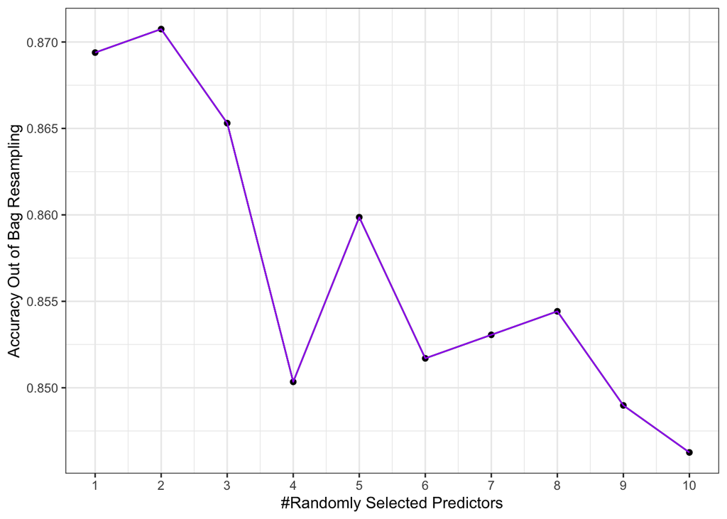

```r
#plot mtry
ggplot(data = rfTuned, aes(x = "Predictors", y = "Accuracy")) +
  scale_x_continuous(breaks = seq(1,10, by = 1)) +
  geom_line(color = "purple") + theme_bw()
```

This plot confirms that 2 is the ideal number of features at each split for this model.

```r
#refit using tuned hyperparameters
set.seed(876)
rfModelFinal = randomForest(HeartDisease ~., data = train,
                            mtry = rfTuned$finalModel$tuneValue$mtry,
                            ntree = 480, importance = T)
rfModelFinal
```

```
##
## Call:
##  randomForest(formula = HeartDisease ~ ., data = train, mtry = rfTuned$finalModel$tuneValue$mtry,      ntree = 480, importance = T)
##                Type of random forest: classification
##                      Number of trees: 480
## No. of variables tried at each split: 2
##
##         OOB estimate of  error rate: 14.01%
## Confusion matrix:
##                noHeartDisease heartDisease class.error
## noHeartDisease            270           58   0.1768293
## heartDisease               45          362   0.1105651
```

I then evaluated my final model by creating a ROC curve and calculating the AUC. The ROC curve shows that the model has high sensitivity and specificity with an AUC of 0.9416. This model is much more accurate than chance alone, showing strong reliability.

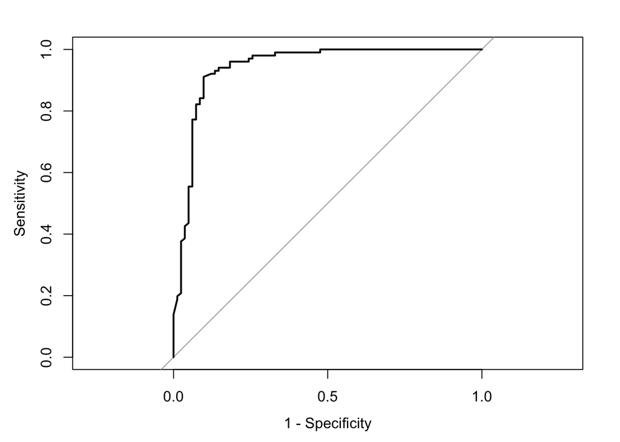

```r
#model evaluation
set.seed(876)
#calculate predicted values
predictTest = predict(rfModelFinal, newdata = test, type = "response")
#calculated predicted probabilities
predictProbTest = predict(rfModelFinal, newdata = test, type = "prob")
#create ROC object and auc curve
ROC = roc(test$HeartDisease~predictProbTest[,2], plot = T, legacy.axes = T)
```

```r
auc(ROC)
```

```
## Area under the curve: 0.9416
```

Now, to identify which 5 variables are the most important in predicting heart disease for this model I created an importance matrix for the final model. This shows the mean decrease in accuracy of the model if the feature is permuted and the mean decrease in Gini impurity if the feature is used. To make the importance matrix easier to interpret I created a plot to visualize the results.

```r
#get VIM
importanceMatrix = rfModelFinal$importance
importanceMatrix
```

```
##                noHeartDisease heartDisease MeanDecreaseAccuracy
## Age               0.012560422 0.0020654240          0.006714758
## Sex               0.013600382 0.0155789930          0.014685483
## ChestPainType     0.040922712 0.0296109703          0.034577194
## RestingBP         0.001202561 0.0029854971          0.002171991
## Cholesterol       0.025503442 0.0143496095          0.019294997
## FastingBS         0.006641585 0.0085374375          0.007713132
## RestingECG        0.002602505 0.0005312128          0.001438921
## MaxHR             0.010927096 0.0228568587          0.017553730
## ExerciseAngina    0.037448423 0.0243975278          0.030253989
## Oldpeak           0.058690883 0.0150099598          0.034360474
## ST_Slope          0.130409852 0.0658432064          0.094467248
##                MeanDecreaseGini
## Age                   27.340890
## Sex                   13.089312
## ChestPainType         40.699458
## RestingBP             23.117626
## Cholesterol           35.840607
## FastingBS              8.666506
## RestingECG             8.871656
## MaxHR                 39.472855
## ExerciseAngina        30.668128
## Oldpeak               42.306101
## ST_Slope              65.769141
```

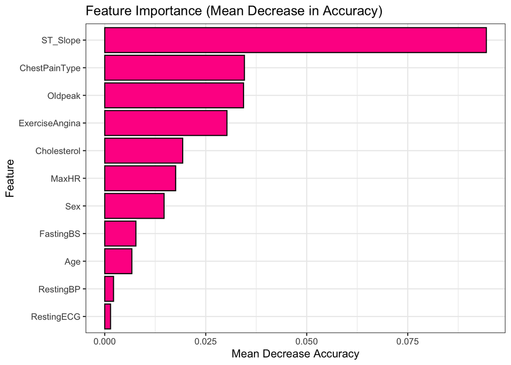

```r
#create VIM plot for final model
impDf = as.data.frame(importanceMatrix)
impDf = cbind(Feature = rownames(impDf), impDf)
rownames(impDf) = NULL
impDf$Feature = factor(impDf$Feature,
                       levels = impDf$Feature[order(impDf$MeanDecreaseAccuracy)])

ggplot(impDf, aes(x = Feature, y = MeanDecreaseAccuracy)) +
  labs(title = "Feature Importance (Mean Decrease in Accuracy)",
       x = "Feature", y = "Mean Decrease Accuracy") +
  coord_flip() +
  geom_col(fill = "deeppink", color = "black") + theme_bw()
```

The plot shows clearly that ST_slope, ExerciseAngina, ChestPainType, Oldpeak, and Cholesterol are the 5 most critical factors to predict heart disease for this model, with ST_slope as the single most important factor.

### Part 3: Create Decision Tree

To ensure that I was using the most accurate model I could create to predict heart disease, I decided to also create a decision tree that predicted heart disease using all features in the dataset. Once again, the data was split into 80% training data and 20% testing data.

```r
#split data for decision tree
set.seed(876)
train.indexDt = createDataPartition(heartClean$HeartDisease, p = 0.8, list = F)
trainDt = heartClean[train.indexDt,]
testDt = heartClean[-train.indexDt,]
```

```r
#create decision tree
set.seed(876)
train.kfold = trainControl(method = "cv", number = 10, savePredictions = T,
                           classProbs = T)
tree.kfold = train(HeartDisease ~., data = trainDt, method = "rpart",
                   trControl = train.kfold, tuneGrid = data.frame(cp = 0.01))
tree.kfold
```

```
## CART
##
## 735 samples
##  11 predictor
##   2 classes: 'noHeartDisease', 'heartDisease'
##
## No pre-processing
## Resampling: Cross-Validated (10 fold)
## Summary of sample sizes: 662, 661, 662, 662, 661, 662, ...
## Resampling results:
##
##   Accuracy   Kappa
##   0.8311366  0.6560811
##
## Tuning parameter 'cp' was held constant at a value of 0.01
```

### Conclusion

By answering my research question I was able to identify ST_slope, ExerciseAngina, ChestPainType, Oldpeak, and Cholesterol as the 5 most important variables in the prediction of heart disease using this dataset. It is important to understand that although these factors were identified as the most important for this model, that does not necessarily mean that these are the most important factors for predicting heart disease in general. Both the random forest and decision tree models were able to achieve good accuracy, with the random forest ultimately having higher accuracy and Kappa levels, making it the best choice for use.